# TN Achievement Gap Story Board

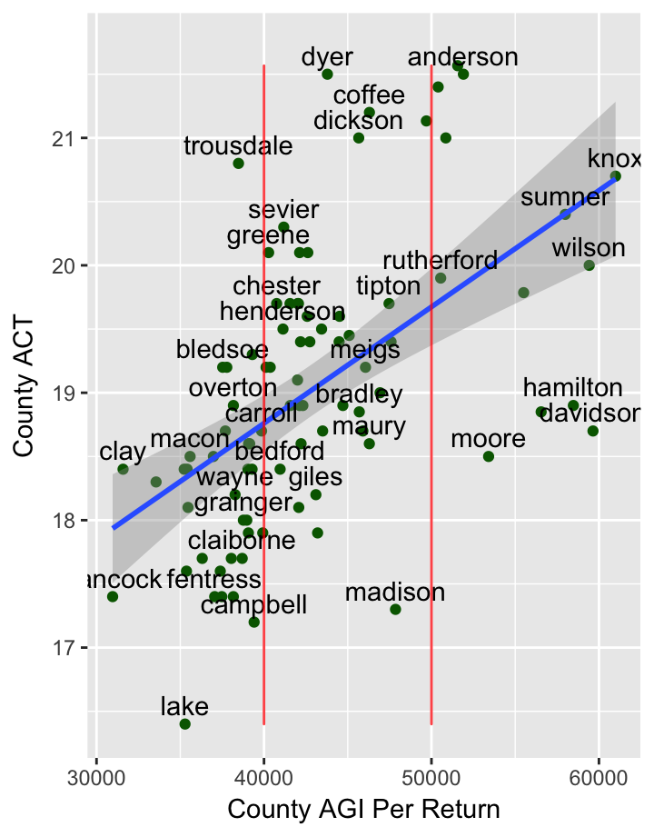

[figure not shown]

### **What is the “ACT Achievement Gap?”**

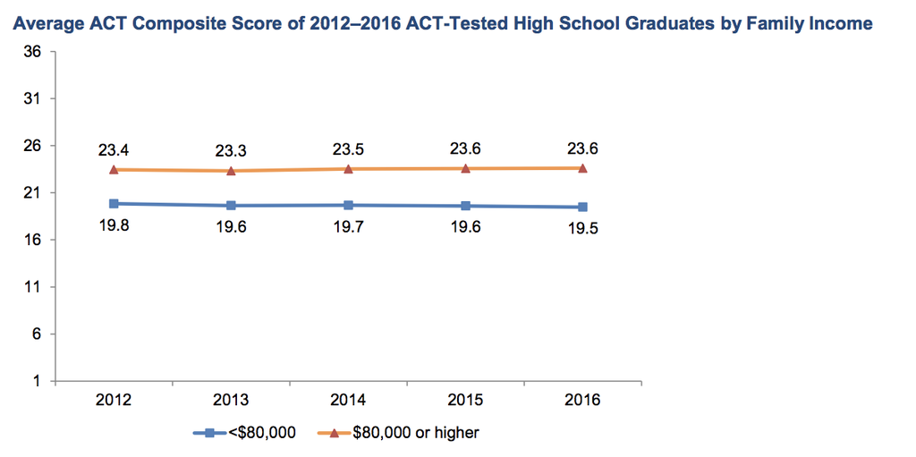

ACT by Family Income

In 2016 ACT [reported](http://www.act.org/content/dam/act/unsecured/documents/R1604-ACT-Composite-Score-by-Family-Income.pdf) that **students, from families with an annual income of $80,000 or more tend to score about four (4) points higher** than students in families that earn less than $80,000 a year.

In 2014 similar results were [reported by the Huffington Post](https://www.huffingtonpost.com/2014/07/18/act-score-family-income_n_5600065.html) and [by the Washington Post](https://www.washingtonpost.com/news/wonk/wp/2014/03/05/these-four-charts-show-how-the-sat-favors-the-rich-educated-families/?utm_term=.56cc245120db) about the ACT and the SAT respectively. And in September 2017, the Washington Post reported that the **Achievement Gap** has, if anything, *worsened* for the ACT: [*‘We didn’t know it was this bad’: New ACT scores show huge achievement gaps*.](https://www.washingtonpost.com/local/education/we-didnt-know-it-was-this-bad-new-act-scores-show-huge-achievement-gaps/2017/09/06/c6397f36-9279-11e7-aace-04b862b2b3f3_story.html?utm_term=.f50e950bb198)

### **How much does it *really* matter?**

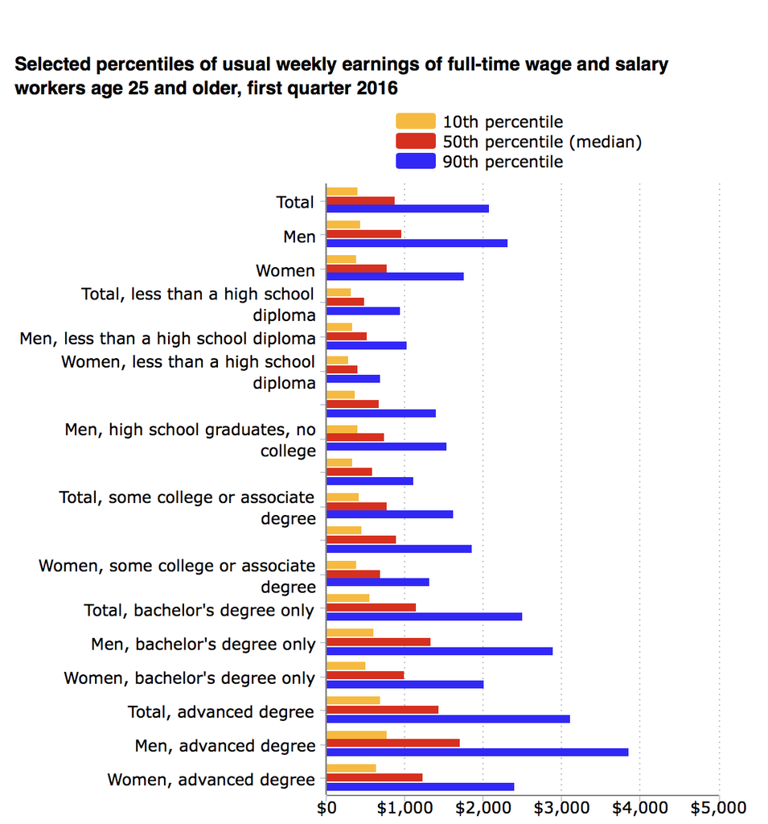

Education and Earning

**It’s kind-of a big deal**

[According to the U.S. Bureau of Labor Statistics](https://www.bls.gov/opub/ted/2016/weekly-earnings-by-educational-attainment-in-first-quarter-2016.htm) for 2016 just *going* to college boosted the average U.S. full-time worker’s median **income from $679/week** to $782. And *graduating with a bachelor’s* boosted that up **to $1,155/week.** a difference of:

- $3,000/month vs $5,000/month
- **$36,000/year vs $60,000/year!** between holding a highschool diploma and bachelor’s degree.

In 2013 the national average ACT composite score was 20.9.

- With standardized-test scores like the SAT and **ACT** being a major (if not the primary) criteria for college admission in the US, **a four (4) point difference is a big difference!**

### **What does the Achievement Gap look like in TN?**

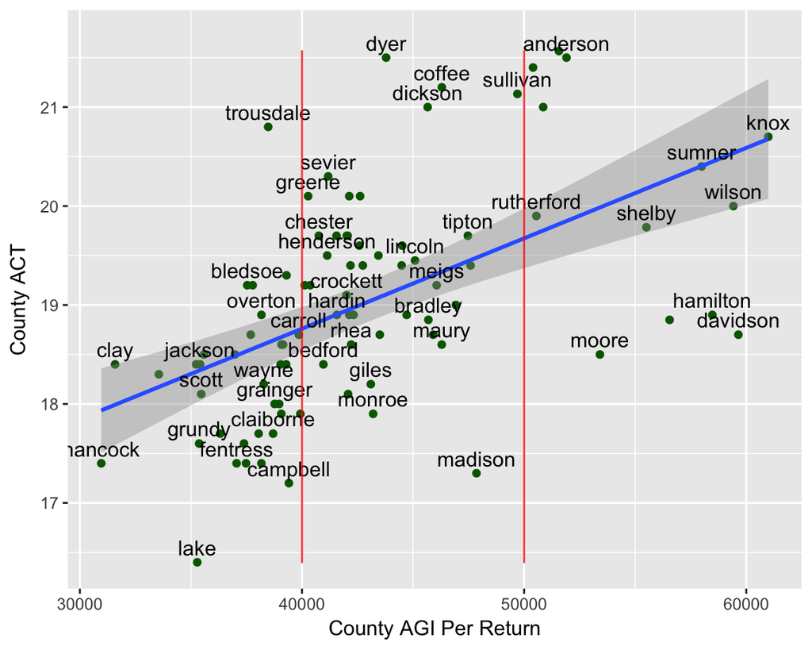

**Correlation of a County’s: AGIncome per Household vs ACT Composite**

- Notice that counties the ACT score distribution for each Income Segment.
- Counties with **“wealthier”** household-income score **no *lower* than 18.5** on the ACT.**
- Counties with **“poorer”** household-income score **no *higher* than 19.5.** (With the exception of trousdale which is on the “wealthier end of the poorest segment.”)**

### **What Else do ACT-Composite Scores Correlate To?**

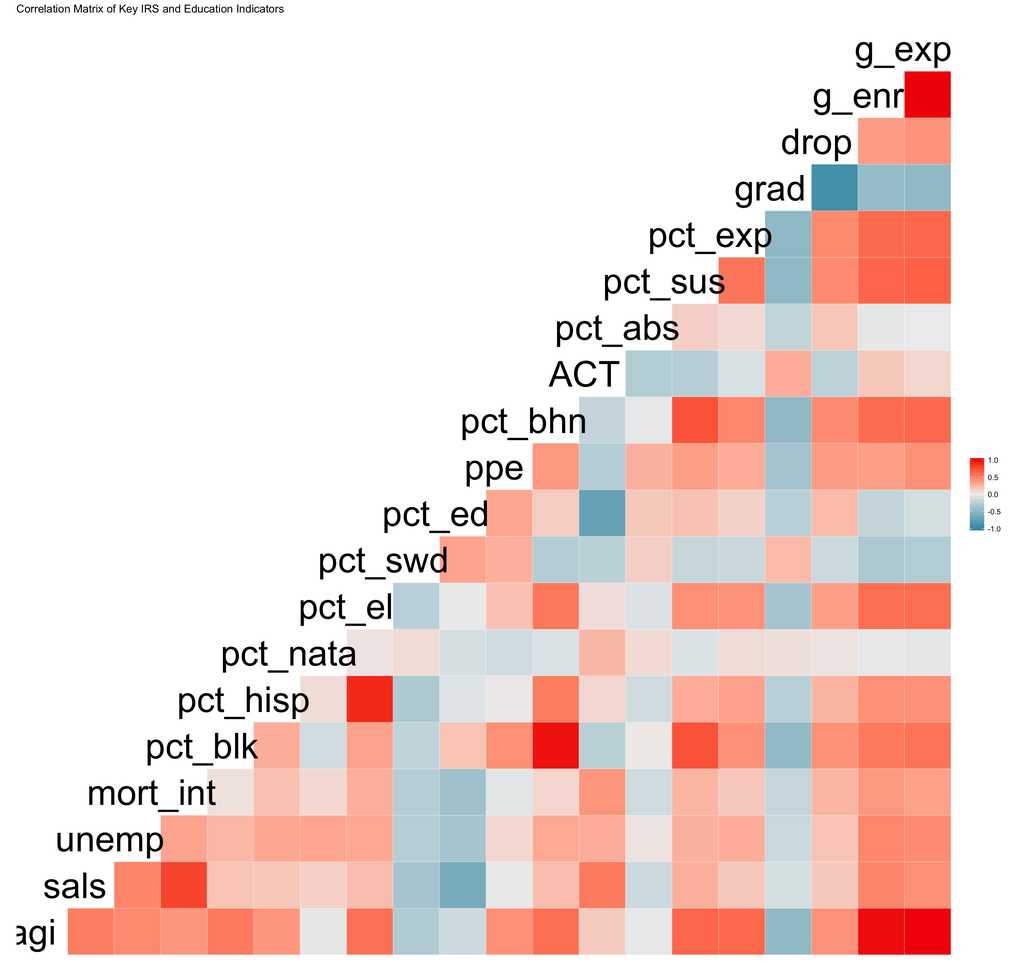

**LEGEND:**

- agi -> adjusted_gross_income
- sals -> salaries_and_wages_in_agi_household
- unemp -> unemployment_compensation_household
- mort_int -> mortgage_interest_paid_household
- pct_blk -> pct_black
- pct_hisp -> pct_hispanic
- pct_nata -> pct_native_american
- pct_el -> pct_EL
- pct_swd -> pct_SWD
- pct_ed -> pct_ED
- ppe -> per_pupil_expenditures
- pct_bhn -> pct_BHN
- ACT -> ACT_composite
- pct_abs -> pct_chronically_absent
- pct_sus -> pct_suspended
- pct_exp -> pct_expelled
- grad -> graduation
- drop -> dropout
- g_enr -> grade_enrollment
- g_exp -> grade_expenditure
- agi_q -> adjusted_gross_income_quantile